# GAMS: An Introduction

Rick Dean

12/15/2019

```r
library(ggplot2)
library(mgcv)
library(dplyr)
library(magrittr)
library(RplotterPkg)
library(RregressPkg)
library(here)
```

Notes and completed tasks from the article [Generalised additive models (GAMs): an introduction](http://environmentalcomputing.net/intro-to-gams/) by Mitchell Lyons.

# Two sets of data to be modeled by GAM

## A simple example

Task: Create some sin wave shaped random data.

```r
set.seed(2)
x <- seq(0, pi * 2, 0.1)
sin_x <- sin(x)
y <- sin_x + rnorm(n = length(x), mean = 0, sd = sd(sin_x/2))
sample_data_df <- data.frame(
  x = x,
  y = y
)
```

Task: Plot the data.

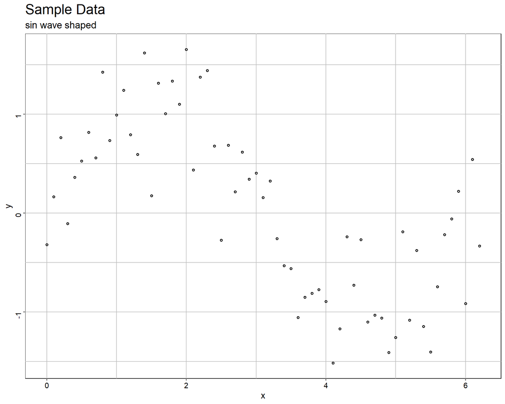

```r
RplotterPkg::create_scatter_plot(
  df = sample_data_df,
  aes_x = "x",
  aes_y = "y",
  title = "Sample Data",
  subtitle = "sin wave shaped"
)
```

Task: From the *mgcv::* package create a GAM model of the data.

```r
gam_model <- mgcv::gam(y ~ s(x), method = "REML", data = sample_data_df)
```

Task: View the summary of the GAM model.

```r
summary(gam_model)
```

```
##
## Family: gaussian
## Link function: identity
##
## Formula:
## y ~ s(x)
##
## Parametric coefficients:
##             Estimate Std. Error t value Pr(>|t|)
## (Intercept)  0.03011    0.05428   0.555    0.581
##
## Approximate significance of smooth terms:
##        edf Ref.df     F p-value
## s(x) 5.498   6.64 29.42  <2e-16 ***
## ---
## Signif. codes:  0 '***' 0.001 '**' 0.01 '*' 0.05 '.' 0.1 ' ' 1
##
## R-sq.(adj) =  0.758   Deviance explained =   78%
## -REML = 45.419  Scale est. = 0.1856    n = 63
```

Task: Check the fitted model over the data.

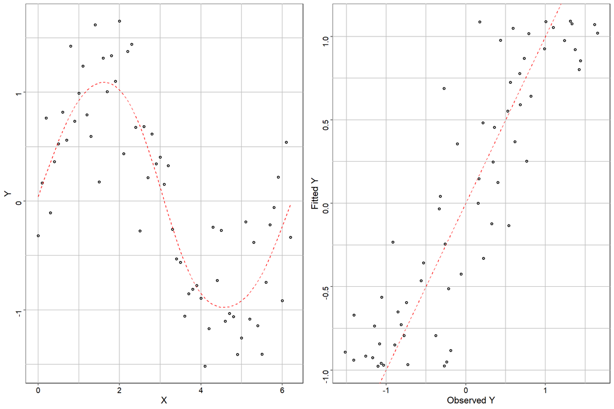

```r
xy_plots <- RregressPkg::plot_xy_fit(
  x = gam_model$model$x,
  y = gam_model$model$y,
  fit = gam_model$fitted.values,
  x_title = "X",
  y_title = "Y",
  col_width = 6,
  row_height = 8
)
```

Task: From the GAM model obtain the basis function values that correspond to the data.

```r
model_basis_data <- mgcv::predict.gam(gam_model, type = "lpmatrix")
```

Task: Multiply the GAM model’s coefficients by the *model_basis_data* to compute and plot the fitted values.

1. Obtain the coefficients and multiply with *model_basis_data*:

```r
model_coef <- gam_model$coefficients
fitted_data <- model_basis_data %*% model_coef
```

2. Plot *fitted_data*:

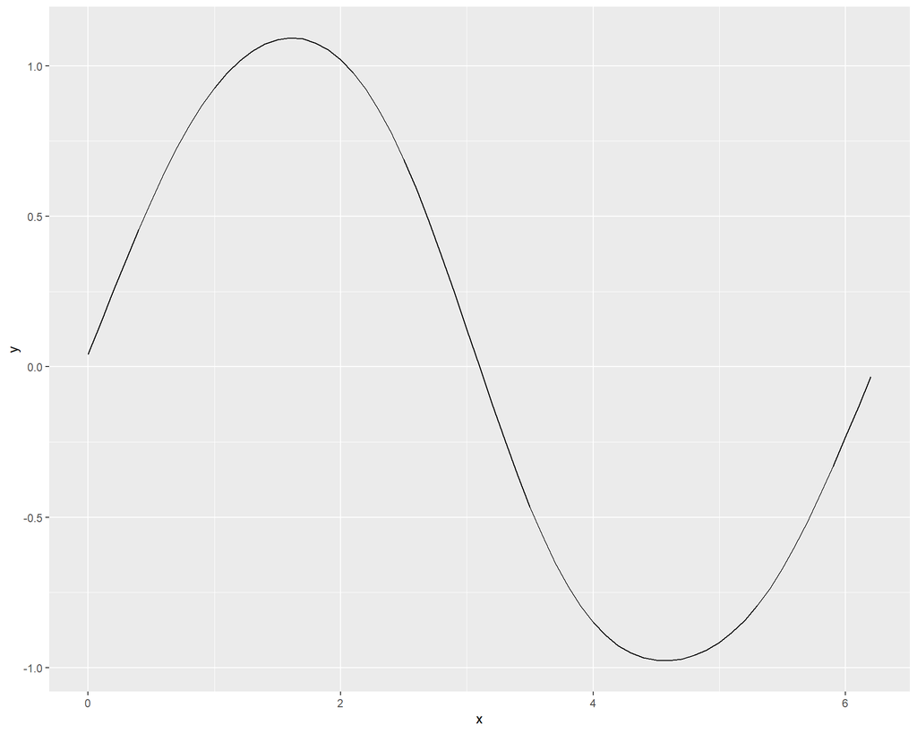

```r
fit_df <- data.frame(
  x = gam_model$model$x,
  y = fitted_data
)
ggplot2::ggplot(data = fit_df, aes(x = x, y = y)) +
  geom_line()
```

Task: Plot the GAM model smooth component using `mgcv::plot_gam()` function.

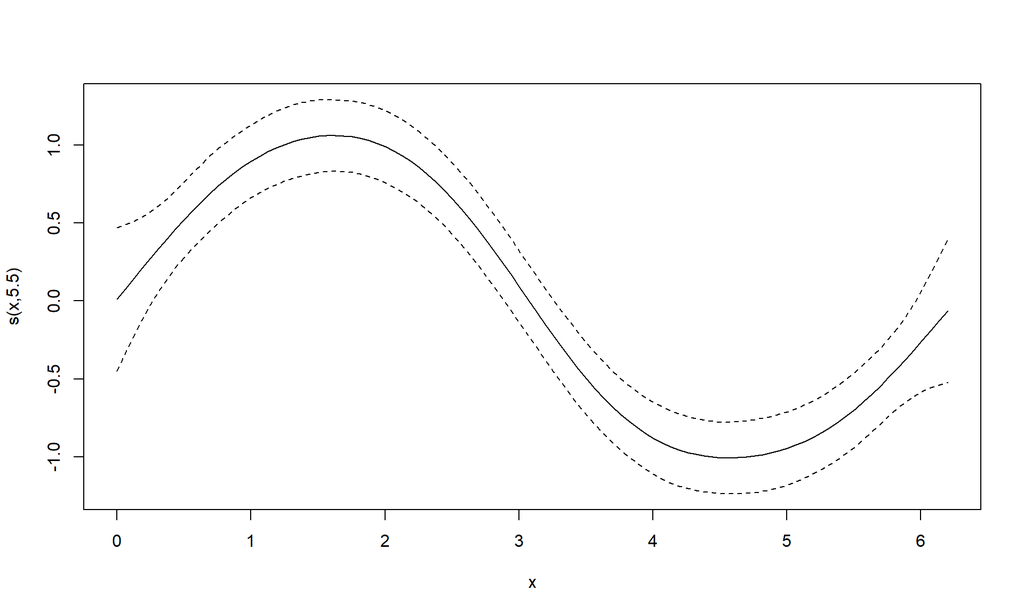

```r
mgcv::plot.gam(x = gam_model, rug = FALSE)
```

Task: Plot the smooth component using `RgamPkg::plot_gam_1d()` function.

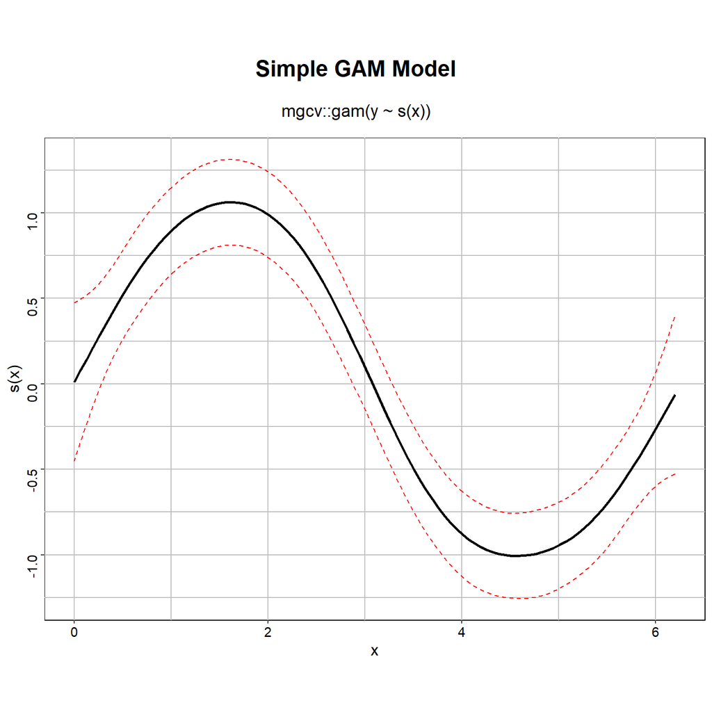

```r
RgamPkg::plot_gam_1d(
  gam_model = gam_model,
  title = "Simple GAM Model",
  subtitle = "mgcv::gam(y ~ s(x))",
  col_width = 8,
  row_height = 6
)
```

Task: Plot the individual spline functions of the “x” smooth using the `RgamPkg::plot_basis_splines_1d()` function.

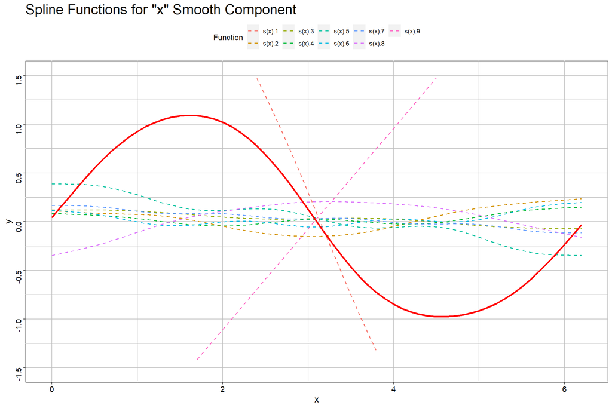

```r
RgamPkg::plot_basis_splines_1d(
  gam_model = gam_model,
  data_var = "x",
  title = 'Spline Functions for "x" Smooth Component',
  y_limits = c(-1.5, 1.5),
  y_major_breaks = seq(-1.5, 1.5, 0.5)
)
```

## A quick real example

Task: Read in the CO2 data from Manua Loa.

```r
data_file <- here("Generalized additive models-an introduction/manua_loa_co2.csv")
co2_df <- read.csv(data_file)
```

Task: Convert the *Date* variable and plot the data.

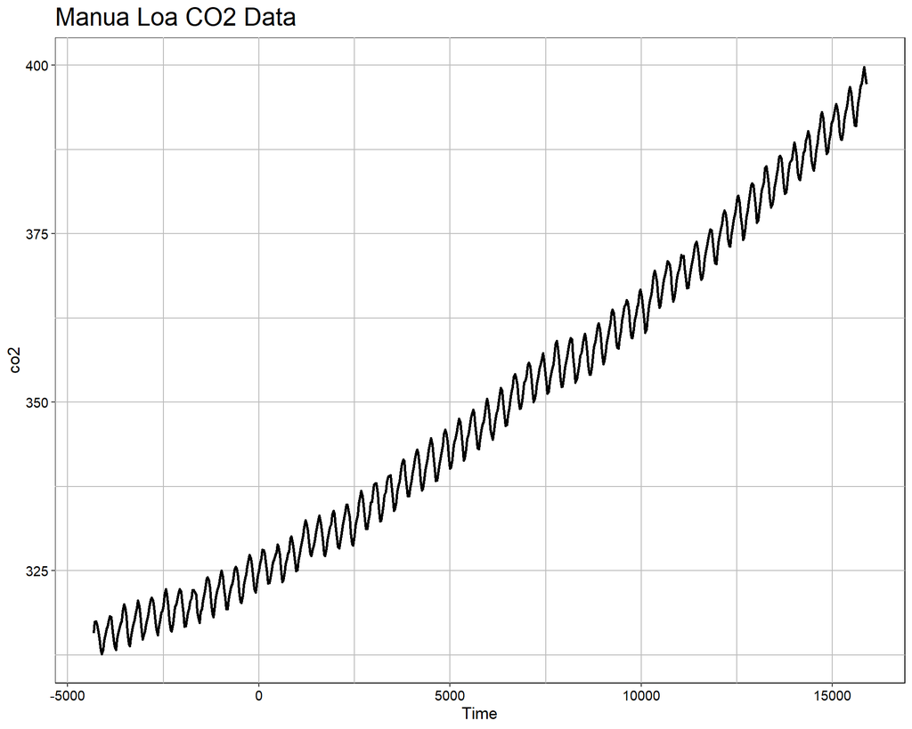

```r
co2_df <- co2_df %>%
  mutate(Time = as.integer(as.Date(Date, format = "%d/%m/%Y")))

RplotterPkg::create_scatter_plot(
  df = co2_df,
  aes_x = "Time",
  aes_y = "co2",
  title = "Manua Loa CO2 Data",
  show_pts = FALSE,
  connect = TRUE,
  rot_y_tic_label = TRUE
)
```

Task: Fit a simple GAM model with a single smooth term for *Time*.

```r
co2_time_gam <- mgcv::gam(co2 ~ s(Time), data = co2_df, method = "REML")
```

Task: Get a summary of the GAM model *co2_time_gam*.

```r
summary(co2_time_gam)
```

```
##
## Family: gaussian
## Link function: identity
##
## Formula:
## co2 ~ s(Time)
##
## Parametric coefficients:
##             Estimate Std. Error t value Pr(>|t|)
## (Intercept) 349.0295     0.0825    4231   <2e-16 ***
## ---
## Signif. codes:  0 '***' 0.001 '**' 0.01 '*' 0.05 '.' 0.1 ' ' 1
##
## Approximate significance of smooth terms:
##           edf Ref.df     F p-value
## s(Time) 7.248  8.265 10104  <2e-16 ***
## ---
## Signif. codes:  0 '***' 0.001 '**' 0.01 '*' 0.05 '.' 0.1 ' ' 1
##
## R-sq.(adj) =  0.992   Deviance explained = 99.2%
## -REML =   1458  Scale est. = 4.5258    n = 665
```

Task: Plot the fitted model over the data.

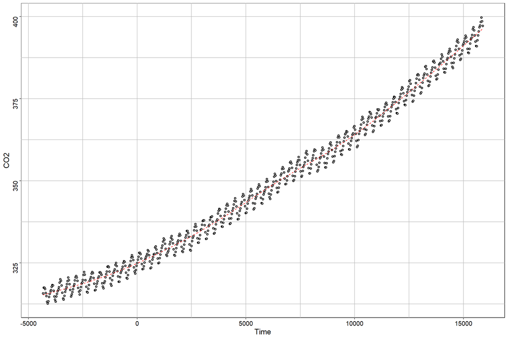

```r
xy_co2_plots <- RregressPkg::plot_xy_fit(
  x = co2_df$Time,
  y = co2_df$co2,
  fit = co2_time_gam$fitted.values,
  x_title = "Time",
  y_title = "CO2",
  display_plot = FALSE
)
xy_co2_plots$x_y_fit_plot
```

Task: Plot CO2 vs the fitted values.

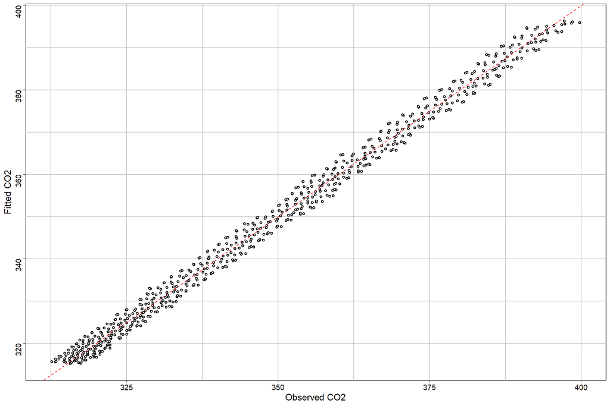

```r
xy_co2_plots$y_fit_plot
```

Task: Plot the GAM model.

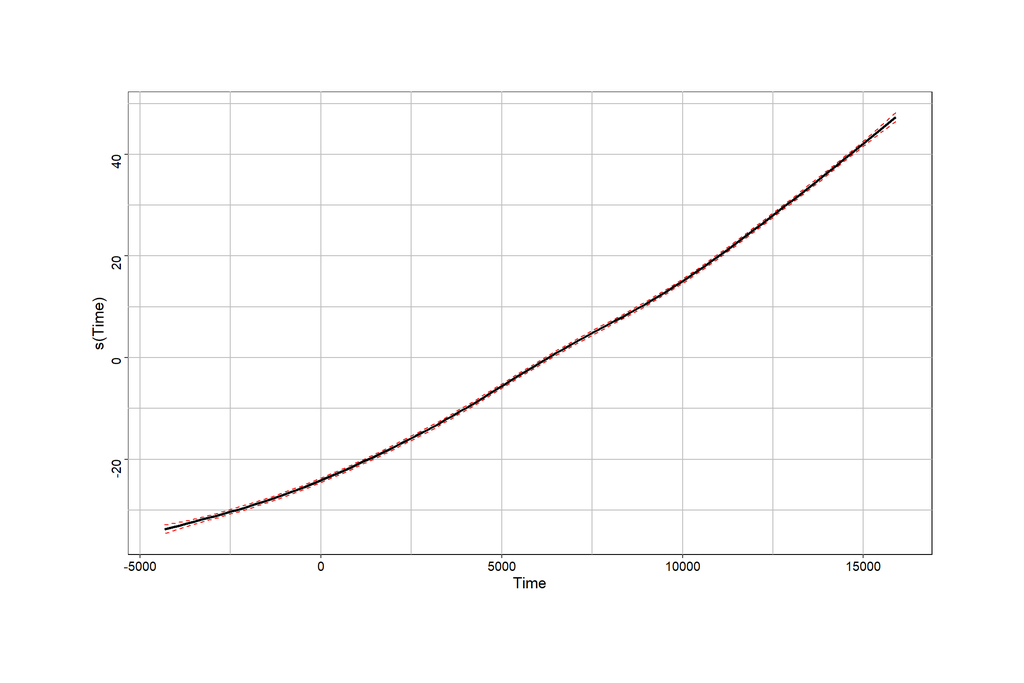

```r
RgamPkg::plot_gam_1d(
  gam_model = co2_time_gam,
  col_width = 10,
  row_height = 6
)
```

Task: Plot the model using the `mgcv::plot.gam()` function.

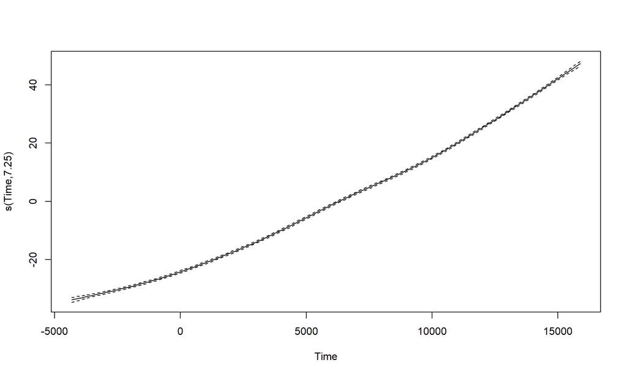

```r
mgcv::plot.gam(co2_time_gam, rug = FALSE)
```

Task: Create a GAM model with a cyclical smooth term.

```r
co2_time_season_gam <- mgcv::gam(co2 ~ s(month, bs = "cc", k = 12) + s(Time), data = co2_df, method = "REML")
summary(co2_time_season_gam)
```

```
##
## Family: gaussian
## Link function: identity
##
## Formula:
## co2 ~ s(month, bs = "cc", k = 12) + s(Time)
##
## Parametric coefficients:
##             Estimate Std. Error t value Pr(>|t|)
## (Intercept) 349.0295     0.0198   17624   <2e-16 ***
## ---
## Signif. codes:  0 '***' 0.001 '**' 0.01 '*' 0.05 '.' 0.1 ' ' 1
##
## Approximate significance of smooth terms:
##            edf Ref.df      F p-value
## s(month) 9.367 10.000   1072  <2e-16 ***
## s(Time)  8.847  8.993 161015  <2e-16 ***
## ---
## Signif. codes:  0 '***' 0.001 '**' 0.01 '*' 0.05 '.' 0.1 ' ' 1
##
## R-sq.(adj) =      1   Deviance explained =  100%
## -REML = 542.85  Scale est. = 0.26082   n = 665
```

Task: Plot the *co2_time_season_gam* model.

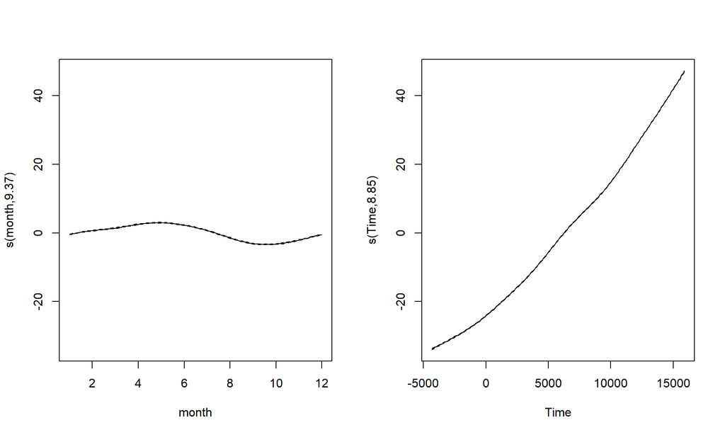

```r
mgcv::plot.gam(co2_time_season_gam, pages = 1, rug = FALSE)
```

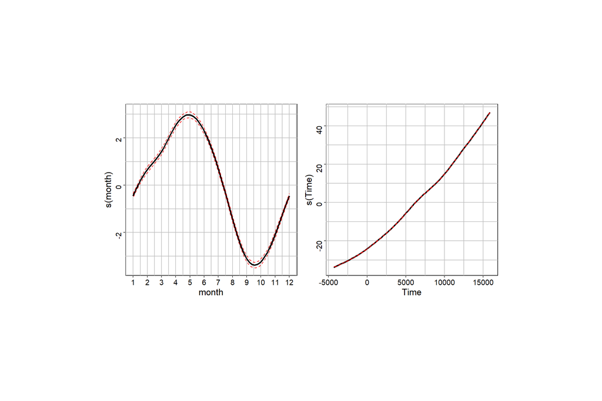

```r
x_major_breaks <- list(
  month = seq(1, 12, 1)
)
RgamPkg::plot_gam_1d(
  gam_model = co2_time_season_gam,
  x_major_breaks = x_major_breaks
)
```